### Question 1

```r
z <- read.table("/Users/irenecho/Desktop/stat443/datafiles/cedata.txt",header=TRUE)
w <- z$FINLWT21  ### sampling weights


zclass <- read.table("/Users/irenecho/Desktop/stat443/datafiles/gf.prp",header=TRUE)
probmissing <- zclass[,2] ### estimated P(INTRDVX_ = C)
p <- 1-probmissing
p
```

```
##    [1] 0.743350 0.720000 0.870260 0.813300 0.844680 0.776600 0.427500 0.560390
##    [9] 0.799860 0.857240 0.457970 0.707110 0.599120 0.668070 0.733360 0.783430
##   [17] 0.372870 0.831960 0.085050 0.233480 0.888240 0.794830 0.821500 0.479880
##   [25] 0.608300 0.681160 0.137320 0.083850 0.796900 0.506360 0.450160 0.460270
##   [33] 0.454560 0.793080 0.722740 0.630990 0.707520 0.577760 0.577980 0.636020
##   [41] 0.832040 0.795690 0.884460 0.749170 0.621550 0.794080 0.644090 0.438500
##   [49] 0.833730 0.434290 0.733220 0.771810 0.865800 0.785750 0.475940 0.867980
##   [57] 0.860120 0.526170 0.776820 0.678250 0.651910 0.495960 0.448060 0.396390
##   [65] 0.147540 0.763160 0.765700 0.655330 0.632230 0.093170 0.835650 0.856180
##   [73] 0.826950 0.801100 0.865600 0.643330 0.178650 0.649120 0.578260 0.734380
##   [81] 0.773030 0.711980 0.558590 0.485350 0.781400 0.385580 0.111380 0.631280
##   [89] 0.828220 0.455440 0.608310 0.628560 0.612390 0.767210 0.857930 0.775400
##   [97] 0.189150 0.666600 0.712460 0.891040 0.863710 0.393110 0.704000 0.718910
##  [105] 0.338340 0.401570 0.828870 0.861760 0.610230 0.752700 0.600540 0.364250
##  [113] 0.879600 0.784330 0.872050 0.571140 0.433050 0.119210 0.709390 0.627270
```

[output cut: 572 more lines]

p in this code should be pi. In the lecture, the professor has mentioned that 1-p(c) = pi. Therefore, I have calculated 1-probmissing,where probmissing equals to p(c). The results for pi equals to the following numbers.

### Question 2

```r
library(rpart)
vartype <- rep("numeric",638)
vartype[c(1,2,4,6,8,10,12,14,16,18,20,22,23,24,25,26,27,29,31,33,34,35,37,39,41,43,45,47,49,52,54,56,58,60,62,64,66,68,70,72,73,74,75,76,77,78,79,80,82,84,86,88,89,90,92,94,96,97,98,99,100,102,104,106,108,109,110,111,112,113,114,115,116,118,119,120,122,123,124,125,126,128,130,131,132,133,135,137,139,303,304,305,306,307,308,309,310,311,312,313,314,315,316,317,318,319,321,323,325,331,333,407,409,410,411,453,454,456,458,460,462,464,465,466,467,468,470,472,474,476,477,478,479,482,484,486,488,490,492,494,496,497,498,499,500,502,504,506,508,510,512,514,516,518,520,522,524,526,528,530,532,534,536,538,540,542,544,546,548,550,552,554,556,558,560,562,564,566,568,570,572,574,576,578,580,582,584,585,586,588,590,592,594,596,598,600,602,604,606,608,610,612,614,616,618,620,622,624,626,628,630,632,635,637)] <- "factor"

z <- read.table(file= "/Users/irenecho/Desktop/stat443/datafiles/subset.txt", header=TRUE, colClasses = vartype)
```

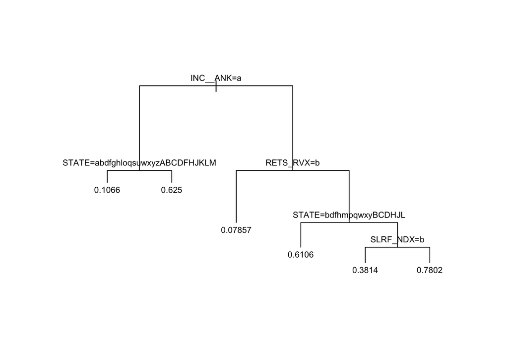

```r
tmp <- rep(NA,nrow(z))
tmp[z$INTRDVX_ == "C"] <- 0
tmp[z$INTRDVX_ == "D" | z$INTRDVX_ == "T"] <- 1
z$INTRDVX_ <- tmp

### regression tree without INTRDVX and FINLWT21
rp <- rpart(INTRDVX_ ~ .- INTRDVX -FINLWT21, data=z, method="anova")
plot(rp,compress=TRUE,margin=0.1)
text(rp, cex=0.7)
```

```r
p <- predict(rp) ### predicted prob(INTRDVX_ = 1)
w <- z$FINLWT21
y <- z$INTRDVX
gp <- !is.na(y)
ipw <- sum(w[gp]*y[gp]/p[gp])/sum(w[gp]/p[gp])
print(ipw)
```

```
## [1] 4442.648
```

The equation for IPW follows:

$$(\sum_{i\in S}^{} w_i/\hat{pi_i})^{-1}\sum_{i\in S}^{} w_i y_i/\hat{pi_i}$$

### Question 3

```r
zreg <- read.table("/Users/irenecho/Desktop/stat443/datafiles/cereg1.fit",header=TRUE)
yhat <- zreg$predicted
yhat
```

```
##    [1]  2607.5880  1596.0370   851.2382  3468.4490   791.1154 35541.9800
##    [7]  3810.0330  5377.4570   955.9800  2165.3370  5400.2790  2876.3290
##   [13]  1981.0570  4367.7110  2483.8720 58172.5400  2662.2800  1204.2190
##   [19]  5767.5170   776.4293   839.3498  6354.3560   704.1825  1223.3080
##   [25]  4622.0750 13894.9600  2926.5970  3163.5070  9969.0340  2218.3900
##   [31]  5521.4430  5154.7560  7155.5350  3299.7260  3014.6190  4067.4400
##   [37]  1375.4320  9008.5380  2926.8240  3471.8900  6980.3570  3506.0290
##   [43]  1215.5870  1344.6020  4673.6510   562.2152  5552.3750  4405.3340
##   [49]  3759.1400   987.6847 14616.6700  1078.4970  2342.1340 14086.2500
##   [55]  1434.3420  1976.6770  2103.5860  2781.1880  1259.9860  8564.8830
##   [61]  3816.7830 20588.6600  3027.1170  1378.0090   997.7417  1400.0770
##   [67] 16763.3900   678.5838 29206.2200  4453.3150  2964.5110  2153.5570
##   [73]  2878.3920  1131.6880  2895.4650  4137.3330  7631.2820  7699.7230
##   [79]   937.3116  3416.6720  2160.7170  4210.3880  6475.4910  5337.5290
##   [85]  1550.6650 11172.8200  3479.1060  1938.4320  1121.9560  3262.3390
```

[output cut: 768 more lines]

The estimate of the missing values of INTRDVX, which is y hat, equals to the following values given above.

### Question 4

```r
y <- z$INTRDVX
w <- z$FINLWT21
miss <- is.na(y) ## obs with missing INTRDVX

rp2 <- rpart(INTRDVX ~ . - INTRDVX_, weight =FINLWT21, data=z,method="anova")
rp2
```

```
## n=2922 (1771 observations deleted due to missingness)
##
## node), split, n, deviance, yval
##       * denotes terminal node
##
##   1) root 2922 1.627725e+16  4696.624
##     2) FINCBT_X=D 2624 1.187559e+15  1821.816 *
##     3) FINCBT_X=T 298 1.062296e+16 31918.830
##       6) FSALARYX>=212524.5 148 1.977165e+15 10078.690
##        12) STATE=1,12,16,17,2,20,21,24,25,27,29,32,33,36,39,41,42,48,51,53,55,6,9 126 5.385303e+13  2184.047 *
##        13) STATE=11,26,34,47 22 1.078676e+15 49096.130
##          26) INC_RANK< 0.99305 10 1.314239e+14  7565.234 *
##          27) INC_RANK>=0.99305 12 3.042116e+14 82649.860 *
##       7) FSALARYX< 212524.5 150 6.014321e+15 54019.280
##        14) RETS_RVX=T 50 6.222578e+14 11980.150
##          28) FINCBTAX< 213208.5 43 3.714334e+13  3322.542 *
##          29) FINCBTAX>=213208.5 7 1.429290e+14 77873.200 *
##        15) RETS_RVX=A,D 100 3.473378e+15 70862.200
##          30) STATE=11,13,16,24,34,41,42,55 20 2.897553e+14 15197.080 *
##          31) STATE=1,12,15,17,18,20,25,26,27,29,32,33,36,39,4,45,48,51,53,6,8,9 80 1.745794e+15 84213.400
##            62) TOTTXPDX< -2150 8 1.263134e+14 18098.420 *
##            63) TOTTXPDX>=-2150 72 9.093254e+14 91097.050
##             126) ROYESTX_=D,T 10 4.113645e+14 53399.160 *
##             127) ROYESTX_=A 62 2.030268e+14 96632.950 *
```

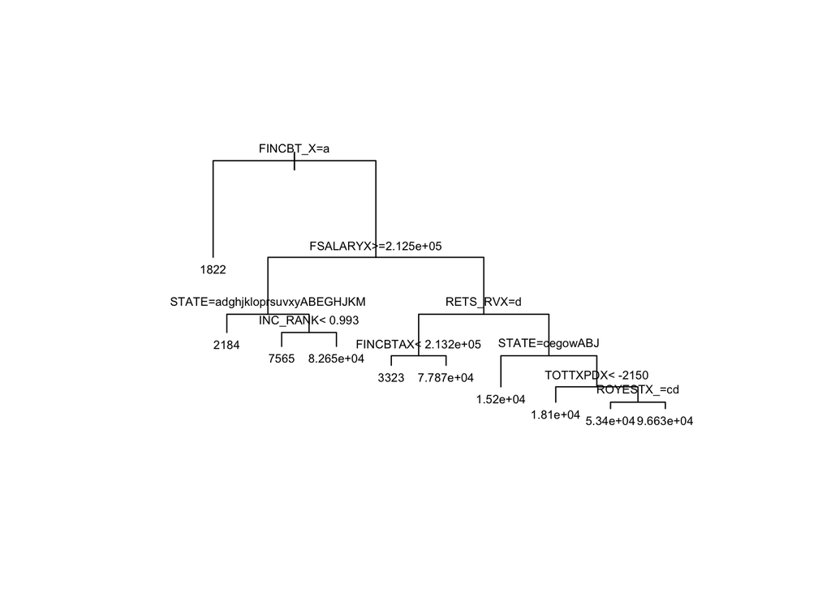

```r
plot(rp2, compress = TRUE, margin=0.2)
text(rp2, cex=0.6)
```

```r
yhat <- predict(rp2,newdata=z)
popmean <- (sum(w[!miss]*y[!miss])+sum(w[miss]*yhat[miss]))/sum(w)
print(popmean)
```

```
## [1] 3996.971
```

The step for this question is similar to Question 1, but I have used cereg.dsc. It is because I should change INTRDVX to D and INTRDVX_ to X (which is already done in cereg.dsc). I have used the R code presented in the ppt slide for the lecture. The estimated population mean of INTRDVX would equal to 3996.971.

Using the similar code to the Question 2, I have calculated imputation method to estimate population mean of INTRDVX. The following equation would be:
$$(\sum_{i}^{ } w_i)^{-1}(\sum_{i\in S}^{ } w_i y_i+\sum_{j\in \bar{S}}^{ }w_j\hat{y_j})$$
The results of the estimate of population mean of INTRDVX would then equal to 3996.971 dollars.